# Week 2 - Exercise (with solution)

## Problem Statement

A perfectly mixed gas permeation module is used to separate carbon dioxide from nitrogen using a poly (2,6-dimethylphenylene oxide) membrane ($P_{CO_2}=0.034\times10^{-13}$ $P_{N_2}=0.089\times10^{-14} [cm^3 (STP) cm / cm^2 s Pa]$). The process carried out at a temperature of 25$^oC$. The feed flowrate is 20.0 mol% carbon dioxide. The module has 15.0 $m^2$ of membrane. The module is operated with a retentate pressure of 5.5 atm and a permeate pressure of 1.01 atm.

The permeate is enriched to 38.0 mol% in carbon dioxide. The membrane thickness is $\ell = 2.0 \times 10^{-4}$ cm.

- Draw a scheme of the unit clearly labelling all the streams and relevant variables.
- Completely characterise the unit, by computing feed, permeate and retentate flow rates, cut, and retentate composition.

## Solution

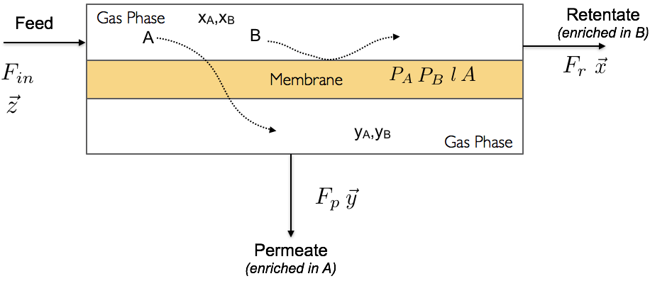

```python
from IPython.display import Image
fig = Image(filename=('./scheme.png'), width=600, height=400)
fig
```

**Unknowns**: $x$,$F_{p}$,$F_{in}$, $F_{r}$, $\theta$

We can start computing the ideal separation factor and the composition in the retentate: \begin{equation} \alpha=P_{CO_2}/P_{N_2} \tag{1} \end{equation} and then using the rate transfer equation to computing $x$: \begin{equation} x=\frac{y\left[1+\frac{p_p}{p_r}(1-y)\left(\alpha_{AB}-1\right)\right]}{\alpha_{AB}-\left(\alpha_{AB}-1\right)y} \label{eq:RTeqsimple}\tag{2} \end{equation}

Then we can compute the cut: \begin{equation} \theta=\frac{z-x}{y-x} \tag{3} \end{equation}

and the permeate flowrate from the flux equation: \begin{equation} Fp=\frac{A*P_{CO_2}\rho_{STP}}{l y}\left(xP_r-yP_p\right) \tag{4} \end{equation}

where $\rho_{STP}$ is the molar density of an ideal gas at standard T and P.

```python
# Variables
A=15 * 1E4 # [m^2 * cm^2 / m^2]
P_r=5.5 * 101325 # [atm] * [Pa / atm]
P_p=1.01 * 101325 # [atm] * [Pa / atm]
l=2.0*1E-4 # cm
rho_STP=1/22.4E3 # / [mol/cm3(stp)]
PCO2=0.034E-13 * 3600 # [cm3(STP) * cm/cm2/s/Pa] * [s/h]
PN2=0.089E-14 * 3600#  [cm3(STP) * cm/cm2/s/Pa] * [s/h]
# Permeate Composition
y=0.38
# Feed Composition
z = 0.20

# 1. compute the retentate composition:
alpha=PCO2/PN2
x= y * (1 + P_p/P_r * (1-y) * (alpha - 1)) / (alpha - (alpha - 1) * y)

# 2. compute the cut:
theta=(z-x)/(y-x)

# 3. compute the permeate flowrate:
Fp=A*PCO2*rho_STP / y / l * (x*P_r-y*P_p)

# 4. compute the feed flowrate:
Fin=Fp/theta

# 5 compute the retentate flowrate:
Fr=Fin-Fp

print("\nRetentate composition: ", f"{x:.4}", " [-]")
print("Cut: ", f"{theta:.4}", "[-]")
print("Permeate flowrate: ", f"{Fp:.4}", " [mol/h]")
print("Feed flowrate: ", f"{Fin:.4}",  " [mol/h]")
print("Retentate flowrate: ", f"{Fr:.4}", " [mol/h]\n")
```

```
Retentate composition:  0.1826  [-]
Cut:  0.08792 [-]
Permeate flowrate:  0.06784  [mol/h]
Feed flowrate:  0.7715  [mol/h]
Retentate flowrate:  0.7037  [mol/h]
```

**The brute force way**

```python
from scipy.optimize import fsolve

# Variables
A=15 * 1E4 # [m^2 * cm^2 / m^2]
P_r=5.5 * 101325 # [atm] * [Pa / atm]
P_p=1.01 * 101325 # [atm] * [Pa / atm]
l=2.0*1E-4 # cm
rho_STP=1/22.4E3 # / [mol/cm3(stp)]
PCO2=0.034E-13 * 3600 # [cm3(STP) * cm/cm2/s/Pa] * [s/h]
PN2=0.089E-14 * 3600#  [cm3(STP) * cm/cm2/s/Pa] * [s/h]
# Permeate Composition
y=0.38
# Feed Composition
z = 0.20

alpha=PCO2/PN2

def equations(vars):
    x, Fin, Fp, Fr, theta = vars
    eq1 = ((theta - 1) / theta) * x + (z / theta) - y
    eq2 = x - (y * (1 + P_p/P_r * (1-y) * (alpha - 1)) / (alpha - (alpha - 1) * y))
    eq3 = Fin - Fr - Fp
    eq4 = Fp-A*PCO2*rho_STP / y / l * (x*P_r-y*P_p)
    eq5 = Fin - (Fp/theta)
    return [eq1, eq2, eq3, eq4, eq5]

x, Fin, Fp, Fr, theta =  fsolve(equations, (0.1, 0.1, 0.1, 0.1, 0.1))

print("\nRetentate composition: ", f"{x:.4}", " [-]")
print("Cut: ", f"{theta:.4}", "[-]")
print("Permeate flowrate: ", f"{Fp:.4}", " [mol/h]")
print("Feed flowrate: ", f"{Fin:.4}",  " [mol/h]")
print("Retentate flowrate: ", f"{Fr:.4}", " [mol/h]\n")
```

```
Retentate composition:  0.1826  [-]
Cut:  0.08792 [-]
Permeate flowrate:  0.06784  [mol/h]
Feed flowrate:  0.7715  [mol/h]
Retentate flowrate:  0.7037  [mol/h]
```